# IODS course project

Otto Halmesvaara

# **Thoughts and Expectations Concerning the Course**

#### How do I feel right now?

I’m alright.

#### What do I expect to learn?

Basics of R.

#### Where did I learn about the course?

A friend told me.

[Link to my GitHub repository](https://github.com/ohwhalme/IODS-project)

# **RStudio Exercise 2: Linear Regression and Model Validation**

### **Before Regression: Inspecting the data with graphs and numbers**

#### **Oppening the data file and inspecting data form and structure**:

```r
data <- read.csv("C:/Users/OHW/Desktop/R/IODS-project/data/learning2014.csv")
data <- dplyr::rename(data, ID = X)
str(data)
```

```
## 'data.frame':    166 obs. of  8 variables:
##  $ ID      : int  1 2 3 4 5 6 7 8 9 10 ...
##  $ Age     : int  53 55 49 53 49 38 50 37 37 42 ...
##  $ gender  : Factor w/ 2 levels "F","M": 1 2 1 2 2 1 2 1 2 1 ...
##  $ Points  : int  25 12 24 10 22 21 21 31 24 26 ...
##  $ Attitude: int  37 31 25 35 37 38 35 29 38 21 ...
##  $ deep    : num  3.58 2.92 3.5 3.5 3.67 ...
##  $ surf    : num  2.58 3.17 2.25 2.25 2.83 ...
##  $ stra    : num  3.38 2.75 3.62 3.12 3.62 ...
```

```r
head(data)
```

```
##   ID Age gender Points Attitude     deep     surf  stra
## 1  1  53      F     25       37 3.583333 2.583333 3.375
## 2  2  55      M     12       31 2.916667 3.166667 2.750
## 3  3  49      F     24       25 3.500000 2.250000 3.625
## 4  4  53      M     10       35 3.500000 2.250000 3.125
## 5  5  49      M     22       37 3.666667 2.833333 3.625
## 6  6  38      F     21       38 4.750000 2.416667 3.625
```

As can be seen from the table above, the data contains 7 measured variables (and participant ID) and 166 answers. The data is structured into a data frame where values participants obtain are coded into rows and variable names are coded into columns. Gender is coded as two level factor (male/female) and the rest are numeric or integer variables.

Now let’s take a closer look at the scales used.

#### **Inspecting the scales:**

```r
summary(data)
```

```
##        ID              Age        gender      Points         Attitude
##  Min.   :  1.00   Min.   :17.00   F:110   Min.   : 7.00   Min.   :14.00
##  1st Qu.: 42.25   1st Qu.:21.00   M: 56   1st Qu.:19.00   1st Qu.:26.00
##  Median : 83.50   Median :22.00           Median :23.00   Median :32.00
##  Mean   : 83.50   Mean   :25.51           Mean   :22.72   Mean   :31.43
##  3rd Qu.:124.75   3rd Qu.:27.00           3rd Qu.:27.75   3rd Qu.:37.00
##  Max.   :166.00   Max.   :55.00           Max.   :33.00   Max.   :50.00
##       deep            surf            stra
##  Min.   :1.583   Min.   :1.583   Min.   :1.250
##  1st Qu.:3.333   1st Qu.:2.417   1st Qu.:2.625
##  Median :3.667   Median :2.833   Median :3.188
##  Mean   :3.680   Mean   :2.787   Mean   :3.121
##  3rd Qu.:4.083   3rd Qu.:3.167   3rd Qu.:3.625
##  Max.   :4.917   Max.   :4.333   Max.   :5.000
```

```r
any(is.na.data.frame(data))
```

```
## [1] FALSE
```

Next let’s examine how the data visually looks with boxplots and density plots.

#### **Boxplots and density plots**

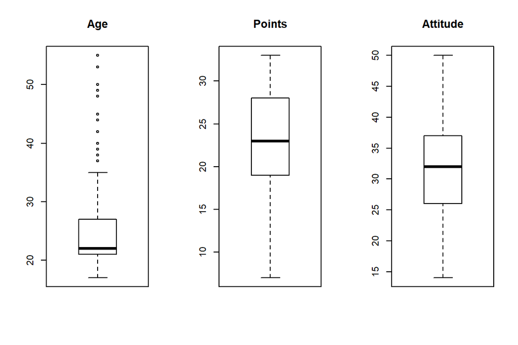

```r
par(mfrow=c(1,3))
boxplot(data$Age, main = "Age")
boxplot(data$Points, main = "Points")
boxplot(data$Attitude, main = "Attitude")
```

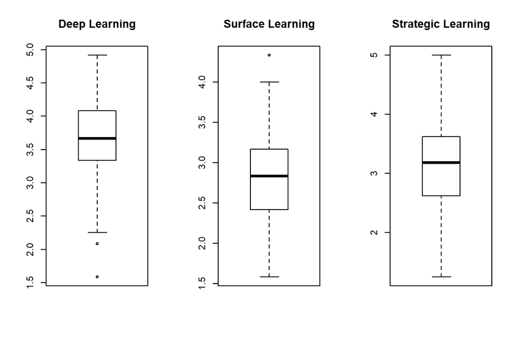

```r
boxplot(data$deep, main = "Deep Learning")
boxplot(data$surf, main = "Surface Learning")
boxplot(data$stra, main = "Strategic Learning")
```

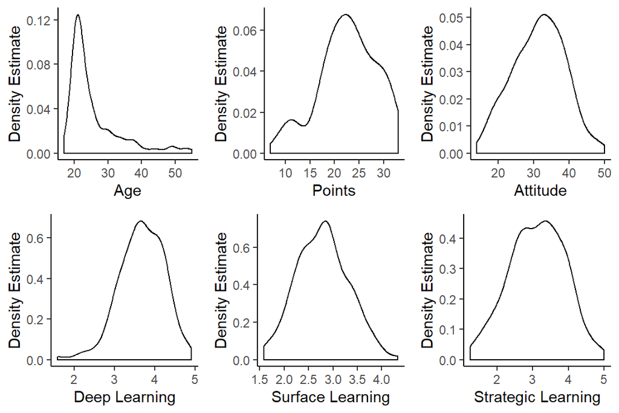

```r
Age_aes <- ggplot(data, aes(data$Age))
Points_aes <- ggplot(data, aes(data$Points))
Attitude_aes <- ggplot(data, aes(data$Attitude))
Deep_aes <- ggplot(data, aes(data$deep))
Surf_aes <- ggplot(data, aes(data$surf))
Stra_aes <- ggplot(data, aes(data$stra))

D1 <- Age_aes + geom_density() + labs(x = "Age", y = "Density Estimate") + theme_classic()
D2 <- Points_aes + geom_density() + labs(x = "Points", y = "Density Estimate") + theme_classic()
D3 <- Attitude_aes + geom_density() + labs(x = "Attitude", y = "Density Estimate") + theme_classic()
D4 <- Deep_aes + geom_density() + labs(x = "Deep Learning", y = "Density Estimate") + theme_classic()
D5 <- Surf_aes + geom_density() + labs(x = "Surface Learning", y = "Density Estimate") + theme_classic()
D6 <- Stra_aes + geom_density() + labs(x = "Strategic Learning", y = "Density Estimate") + theme_classic()

gridExtra::grid.arrange(D1, D2, D3, D4, D5, D6, nrow = 2)
```

Now let’s look how the potential explanatory variables are related to the response variable (i.e. to the “Points”).

#### **Scatterplots**

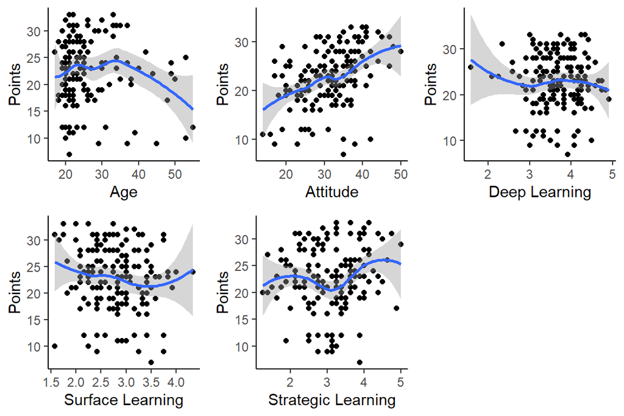

```r
Age_scatter <- ggplot(data, aes(Age, Points))
Attitude_scatter <- ggplot(data, aes(Attitude, Points))
Deep_scatter <- ggplot(data, aes(deep, Points))
Surf_scatter <- ggplot(data, aes(surf, Points))
Stra_scatter <- ggplot(data, aes(stra, Points))

S1 <- Age_scatter + geom_point() + geom_smooth() + labs(x = "Age", y = "Points") + theme_classic()
S2 <- Attitude_scatter + geom_point() + geom_smooth() + labs(x = "Attitude", y = "Points") + theme_classic()
S3 <- Deep_scatter + geom_point() + geom_smooth() + labs(x = "Deep Learning", y = "Points") + theme_classic()
S4 <- Surf_scatter + geom_point() + geom_smooth() + labs(x = "Surface Learning", y = "Points") + theme_classic()
S5 <- Stra_scatter + geom_point() + geom_smooth() + labs(x = "Strategic Learning", y = "Points") + theme_classic()

gridExtra::grid.arrange(S1, S2, S3, S4, S5, nrow = 2)
```

The scatterplots indicate that only “Attitude” variable has, at face value, linear relationship with “Points” variable. The relationship between other variables and “Points” seems to show signs of curvilinearity. Possible reasons for this could be that the relationship between the variables is actually nonlinear or that some outlier values distorts the relationship.

We will quickly take a look at some of the potential outliers by using bivariate boxplots. According to Vehkalahti & Everitt (2019) bivariate boxplots can be defined as “The bivariate boxplot is based on calculating robust measures of location, scale, and correlation; it consists essentially of a pair of concentric ellipses, one of which (the “hinge”) includes 50% of the data, and the other (called the “fence”) which delineates potential troublesome outliers. In addition, resistant regression lines of both y on x and x on y are shown, with their intersection showing the bivariate locations estimator. The acute angle between the regression lines will be small for a large absolute value of correlations and large for a small one." (the “fence” equals 99 % CI here).

#### **Bivariate boxplots for outliers**

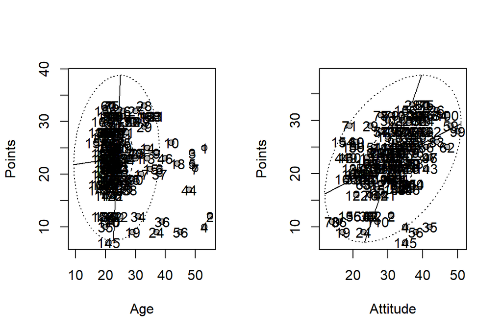

```r
par(mfrow=c(1,2))
asbio::bv.boxplot(data$Age, data$Points, robust = TRUE, D = 7, xlab = "Age", ylab = "Points")
text(data$Age, data$Points, labels=data$ID)
asbio::bv.boxplot(data$Attitude, data$Points, robust = TRUE, D = 7, xlab = "Attitude", ylab = "Points")
text(data$Attitude, data$Points, labels=data$ID)
```

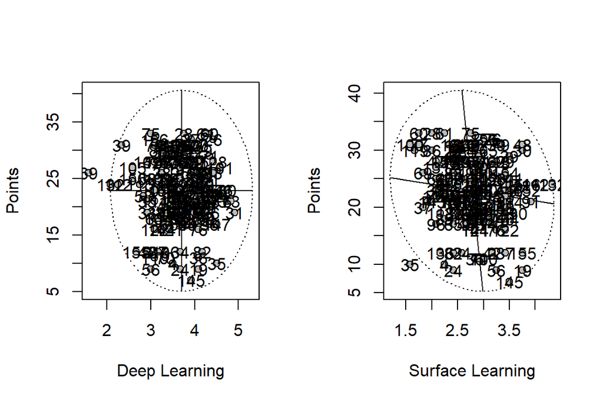

```r
asbio::bv.boxplot(data$deep, data$Points, robust = TRUE, D = 7, xlab = "Deep Learning", ylab = "Points")
text(data$deep, data$Points, labels=data$ID)
asbio::bv.boxplot(data$surf, data$Points, robust = TRUE, D = 7, xlab = "Surface Learning", ylab = "Points")
text(data$surf, data$Points, labels=data$ID)
```

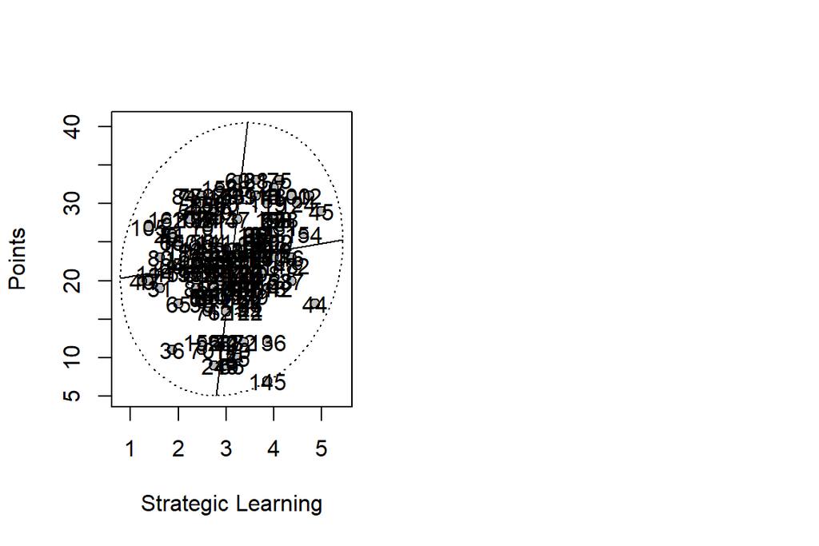

```r
asbio::bv.boxplot(data$stra, data$Points, robust = TRUE, D = 7, xlab = "Strategic Learning", ylab = "Points")
text(data$stra, data$Points, labels=data$ID)
```

The bivariate boxplots shows that there multiple potential outliers in the relationship between “Age” and “Points” and few outliers with the other variables as well. We will need to keep this in mind when we start fitting the regression model and be prepared to remove some of the more influential outliers. (Note that participant id is added as a label so outliers can be more easily identified later)

Finally, let’s investigate the correlations between the variables (although, the aforementioned outliers could prove to be problematic here too).

#### **Pearson’s r and Kendall’s tau correlation coefficients**

```r
Correlations <- select(data, -gender, -ID)
psych::corr.test(Correlations, y = NULL, use = "pairwise", method = "pearson", adjust = "none", alpha = .05, ci = FALSE, minlength = 7)
```

```
## Call:psych::corr.test(x = Correlations, y = NULL, use = "pairwise",
##     method = "pearson", adjust = "none", alpha = 0.05, ci = FALSE,
##     minlength = 7)
## Correlation matrix
##            Age Points Attitude  deep  surf  stra
## Age       1.00  -0.09     0.02  0.03 -0.14  0.10
## Points   -0.09   1.00     0.44 -0.01 -0.14  0.15
## Attitude  0.02   0.44     1.00  0.11 -0.18  0.06
## deep      0.03  -0.01     0.11  1.00 -0.32  0.10
## surf     -0.14  -0.14    -0.18 -0.32  1.00 -0.16
## stra      0.10   0.15     0.06  0.10 -0.16  1.00
## Sample Size
## [1] 166
## Probability values (Entries above the diagonal are adjusted for multiple tests.)
##           Age Points Attitude deep surf stra
## Age      0.00   0.23     0.78 0.75 0.07 0.19
## Points   0.23   0.00     0.00 0.90 0.06 0.06
## Attitude 0.78   0.00     0.00 0.16 0.02 0.43
## deep     0.75   0.90     0.16 0.00 0.00 0.22
## surf     0.07   0.06     0.02 0.00 0.00 0.04
## stra     0.19   0.06     0.43 0.22 0.04 0.00
##
##  To see confidence intervals of the correlations, print with the short=FALSE option
```

```r
psych::corr.test(Correlations, y = NULL, use = "pairwise", method = "kendall", adjust = "none", alpha = .05, ci = FALSE, minlength = 7)
```

```
## Call:psych::corr.test(x = Correlations, y = NULL, use = "pairwise",
##     method = "kendall", adjust = "none", alpha = 0.05, ci = FALSE,
##     minlength = 7)
## Correlation matrix
##            Age Points Attitude  deep  surf  stra
## Age       1.00   0.05    -0.01  0.01 -0.11  0.04
## Points    0.05   1.00     0.32 -0.01 -0.10  0.12
## Attitude -0.01   0.32     1.00  0.07 -0.12  0.05
## deep      0.01  -0.01     0.07  1.00 -0.23  0.08
## surf     -0.11  -0.10    -0.12 -0.23  1.00 -0.11
## stra      0.04   0.12     0.05  0.08 -0.11  1.00
## Sample Size
## [1] 166
## Probability values (Entries above the diagonal are adjusted for multiple tests.)
##           Age Points Attitude deep surf stra
## Age      0.00   0.56     0.93 0.86 0.16 0.65
## Points   0.56   0.00     0.00 0.90 0.20 0.11
## Attitude 0.93   0.00     0.00 0.40 0.12 0.48
## deep     0.86   0.90     0.40 0.00 0.00 0.33
## surf     0.16   0.20     0.12 0.00 0.00 0.14
## stra     0.65   0.11     0.48 0.33 0.14 0.00
##
##  To see confidence intervals of the correlations, print with the short=FALSE option
```

Kendall’s tau and Pearson’s r give fairly similar estimates here for correlations between “Points” and the explanatory variables. There is practially no correlation between “Points” and “Age” or “Deep Learning”. There seens to be small correlations between “Points” and “Surface Learning” or “Strategic Learning”. The only correlation which is quite large and also statistically significant (with the .05 alpha level for both tau and r) is between “Attitude” and “Points”. However, some caution should be applied here since we earlier found quite many outliers and signs of nonlinear relationship between “Points” and many of the other variables.

### **Regression: Model fitting and validation**

Based on the information we learned from the correlations, it seems “Attitude” will probably be the strongest predictor for “Points”, so we will add that as the main predictor. We will also test whether adding the learning variables to the model will improve the model fit and if participant gender has any effect in this contex. “Age” variable is dropped at this point, since the earlier inspections revealed problems with the distribution, outliers, and low correlation with the response variable.

#### **Basic Model: Points ~ Attitude:**

```r
m1 <- lm(Points ~ Attitude, data = data)
summary(m1)
```

```
##
## Call:
## lm(formula = Points ~ Attitude, data = data)
##
## Residuals:
##      Min       1Q   Median       3Q      Max
## -16.9763  -3.2119   0.4339   4.1534  10.6645
##
## Coefficients:
##             Estimate Std. Error t value Pr(>|t|)
## (Intercept) 11.63715    1.83035   6.358 1.95e-09 ***
## Attitude     0.35255    0.05674   6.214 4.12e-09 ***
## ---
## Signif. codes:  0 '***' 0.001 '**' 0.01 '*' 0.05 '.' 0.1 ' ' 1
##
## Residual standard error: 5.32 on 164 degrees of freedom
## Multiple R-squared:  0.1906, Adjusted R-squared:  0.1856
## F-statistic: 38.61 on 1 and 164 DF,  p-value: 4.119e-09
```

Here we can see that the model fit significantly improves when we are using the model based on “Attitude” variable (instead of the response variable mean) to predict “Points” variable, F(1, 164) = 38.61, p <. 001. R2 indicates that the model accounts 19.1 % of the variation in the “Points” variable. From the model coefficients we can see that, on average, when the “Attitude” variable increases one unit the “Points” variable increases 0.35 units.

Now, let’s add the learning variables to the model to see if our model fit further improves.

#### **Model2: Points ~ Attitude + surf + deep + stra:**

```r
m2 <- update(m1, .~. + surf + deep + stra, data = data)
summary(m2)
```

```
##
## Call:
## lm(formula = Points ~ Attitude + surf + deep + stra, data = data)
##
## Residuals:
##      Min       1Q   Median       3Q      Max
## -16.7335  -3.1992   0.7975   3.4002  11.6582
##
## Coefficients:
##             Estimate Std. Error t value Pr(>|t|)
## (Intercept) 15.39999    5.02450   3.065  0.00255 **
## Attitude     0.34362    0.05739   5.987 1.34e-08 ***
## surf        -0.91045    0.83901  -1.085  0.27948
## deep        -1.00721    0.78702  -1.280  0.20247
## stra         0.88475    0.54110   1.635  0.10398
## ---
## Signif. codes:  0 '***' 0.001 '**' 0.01 '*' 0.05 '.' 0.1 ' ' 1
##
## Residual standard error: 5.286 on 161 degrees of freedom
## Multiple R-squared:  0.2154, Adjusted R-squared:  0.1959
## F-statistic: 11.05 on 4 and 161 DF,  p-value: 6.057e-08
```

```r
lms1 <- list(m1, m2)
lm.select(lms1)
```

```
##                                    Model      AIC     AICc      BIC
## 1                      Points ~ Attitude 1029.988 1030.136 1039.323
## 2 Points ~ Attitude + surf + deep + stra 1030.811 1031.339 1049.483
##         Cp    PRESS
## 1 4.000000 4758.259
## 2 4.964364 4770.407
```

R2 did not notably increase or AIC (Akaike Information Criterion) decrease after adding the learning variables. Moreover, when all the other variables are kept constant in the model, none of the learning variables regression slopes significantly differ from zero (all ps > .10). Also, “Attitude” variable is not noticeably affected by the addition of the learning variables. To sum up, learning variables seems to add very little to our model. Thus, to be parsimonious, we will drop these variables out of the model.

Next let’s see if participant gender has any effect for our model

#### **Model3: Points ~ Attitude + gender:**

```r
m3 <- update(m1, .~. + gender, data = data)
summary(m3)
```

```
##
## Call:
## lm(formula = Points ~ Attitude + gender, data = data)
##
## Residuals:
##      Min       1Q   Median       3Q      Max
## -17.1724  -3.2092   0.3703   4.0197  10.6162
##
## Coefficients:
##             Estimate Std. Error t value Pr(>|t|)
## (Intercept)  11.5098     1.8502   6.221 4.01e-09 ***
## Attitude      0.3618     0.0595   6.081 8.21e-09 ***
## genderM      -0.4835     0.9157  -0.528    0.598
## ---
## Signif. codes:  0 '***' 0.001 '**' 0.01 '*' 0.05 '.' 0.1 ' ' 1
##
## Residual standard error: 5.331 on 163 degrees of freedom
## Multiple R-squared:  0.1919, Adjusted R-squared:  0.182
## F-statistic: 19.36 on 2 and 163 DF,  p-value: 2.863e-08
```

```r
lms2 <- list(m1, m3)
lm.select(lms2)
```

```
##                        Model      AIC     AICc      BIC       Cp    PRESS
## 1          Points ~ Attitude 1029.988 1030.136 1039.323 4.000000 4758.259
## 2 Points ~ Attitude + gender 1031.704 1031.952 1044.152 5.719976 4809.312
```

R2 increased only marginally and AIC did not decrease. Again, “Attitude” variables estimates remains largely unchanged. This indicates that gender is not that important variable in this context. Thus, our final model will be just “Attitude” predicting “Points”.

Up to this point, we have largely ignored any potential problems within our model. Now it’s time to take closer look at the model diagnostics.

#### **Model diagnostics:**

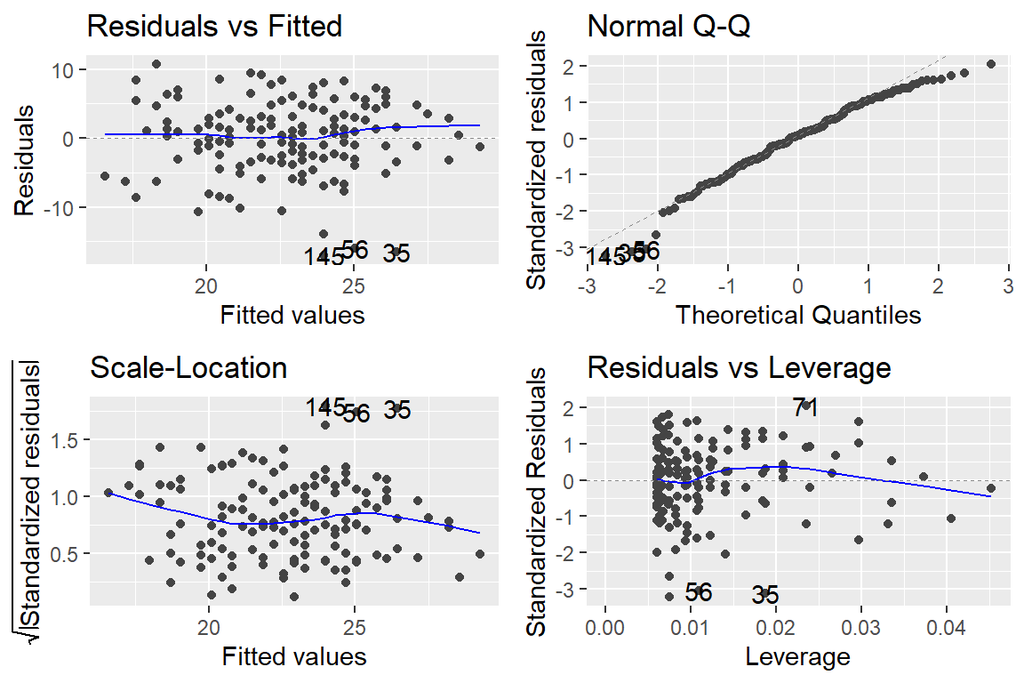

```r
autoplot(m1)
```

**Residuals vs Fitted.** From the first plot we will inspect how well the assumptions of random errors and homoscedasticity are met. The plot should look like a random array of dots evenly dispersed around zero. There is no noticeable curvature or funnel shape in the data, which implies that there is no serious violation of the assumptions. The same outliers that we identified with the bivariate boxplot are also shown here.

**Normal Q-Q.** If the residuals are normally distributed the dots should closely track the dotted line spliting the plot. Here, the distribution seems to be roughly normal, even though there is some curvature toward the top corner. Again, the same three outliers can be seen at the bottom corner.

**Scale-Location.** This plot is another way to check the homogeneity of variance of the residuals. The plot should ideally include straight horizontal line with random array of dots on each side. The plot obviously is not ideal here, but there is no cause for serious concern.

**Residuals vs Leverage.** From here we can inspect if there are influential cases in the model (i.e. obervations with undue influence to the estimation). From the plot we can see that two of the outlier residuals exceeds 3 standard deviation, but their leverage values are not very high. Let’s examine the Cook’s distance values to be sure.

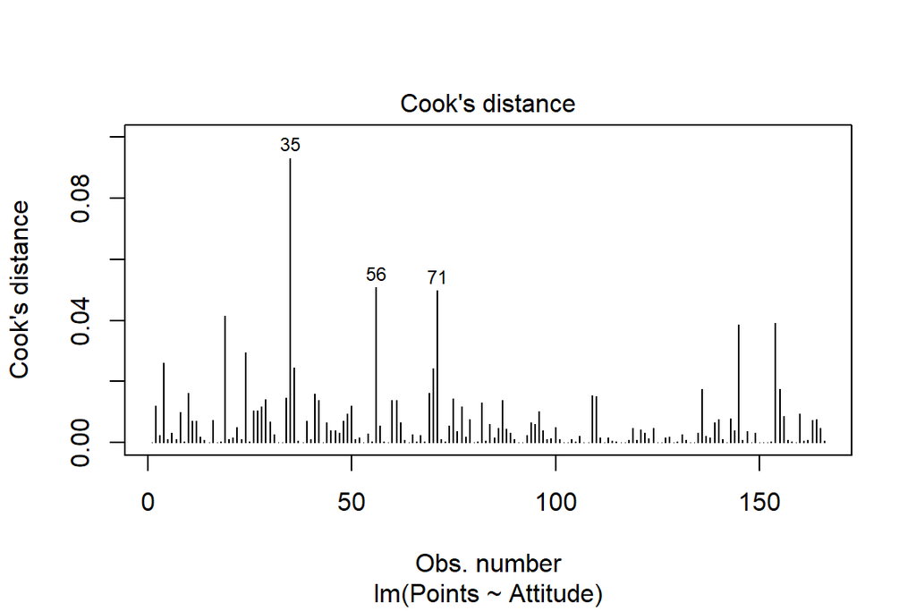

```r
plot(m1, 4)
```

Although the case 35 is quite much higher than the rest, all of the values are still below 1 so there should not be cause for great concern.

If the model assumptions would have been more seriously violated, we could have tried to do some data transformations (though, these dont always help with residuals) or possibly use robust regression.

# **RStudio Exercise 3: Logistic Regression**

For explanation how the data set was created see: https://mooc.helsinki.fi/course/view.php?id=273#section-3 and R script: https://github.com/ohwhalme/IODS-project/blob/master/data/data_ex3.R

#### **Oppening the data file and inspecting data form and structure**:

```r
data <- read.csv("C:/Users/OHW/Desktop/R/IODS-project/data/alc.csv")
data <- dplyr::rename(data, ID = X)
str(data)
```

```
## 'data.frame':    382 obs. of  36 variables:
##  $ ID        : int  1 2 3 4 5 6 7 8 9 10 ...
##  $ school    : Factor w/ 2 levels "GP","MS": 1 1 1 1 1 1 1 1 1 1 ...
##  $ sex       : Factor w/ 2 levels "F","M": 1 1 1 1 1 2 2 1 2 2 ...
##  $ age       : int  18 17 15 15 16 16 16 17 15 15 ...
##  $ address   : Factor w/ 2 levels "R","U": 2 2 2 2 2 2 2 2 2 2 ...
##  $ famsize   : Factor w/ 2 levels "GT3","LE3": 1 1 2 1 1 2 2 1 2 1 ...
##  $ Pstatus   : Factor w/ 2 levels "A","T": 1 2 2 2 2 2 2 1 1 2 ...
##  $ Medu      : int  4 1 1 4 3 4 2 4 3 3 ...
##  $ Fedu      : int  4 1 1 2 3 3 2 4 2 4 ...
##  $ Mjob      : Factor w/ 5 levels "at_home","health",..: 1 1 1 2 3 4 3 3 4 3 ...
##  $ Fjob      : Factor w/ 5 levels "at_home","health",..: 5 3 3 4 3 3 3 5 3 3 ...
##  $ reason    : Factor w/ 4 levels "course","home",..: 1 1 3 2 2 4 2 2 2 2 ...
##  $ nursery   : Factor w/ 2 levels "no","yes": 2 1 2 2 2 2 2 2 2 2 ...
##  $ internet  : Factor w/ 2 levels "no","yes": 1 2 2 2 1 2 2 1 2 2 ...
```

[output cut: 22 more lines]

```r
glimpse(data)
```

```
## Observations: 382
## Variables: 36
## $ ID         <int> 1, 2, 3, 4, 5, 6, 7, 8, 9, 10, 11, 12, 13, 14, 15, ...
## $ school     <fct> GP, GP, GP, GP, GP, GP, GP, GP, GP, GP, GP, GP, GP,...
## $ sex        <fct> F, F, F, F, F, M, M, F, M, M, F, F, M, M, M, F, F, ...
## $ age        <int> 18, 17, 15, 15, 16, 16, 16, 17, 15, 15, 15, 15, 15,...
## $ address    <fct> U, U, U, U, U, U, U, U, U, U, U, U, U, U, U, U, U, ...
## $ famsize    <fct> GT3, GT3, LE3, GT3, GT3, LE3, LE3, GT3, LE3, GT3, G...
## $ Pstatus    <fct> A, T, T, T, T, T, T, A, A, T, T, T, T, T, A, T, T, ...
## $ Medu       <int> 4, 1, 1, 4, 3, 4, 2, 4, 3, 3, 4, 2, 4, 4, 2, 4, 4, ...
## $ Fedu       <int> 4, 1, 1, 2, 3, 3, 2, 4, 2, 4, 4, 1, 4, 3, 2, 4, 4, ...
## $ Mjob       <fct> at_home, at_home, at_home, health, other, services,...
## $ Fjob       <fct> teacher, other, other, services, other, other, othe...
## $ reason     <fct> course, course, other, home, home, reputation, home...
## $ nursery    <fct> yes, no, yes, yes, yes, yes, yes, yes, yes, yes, ye...
```

[output cut: 23 more lines]

```r
any(is.na.data.frame(data))
```

```
## [1] FALSE
```

There are no missing values. The data contains 382 observations (rows) and 35 + 1 variables (columns). + 1 being participant ID. Thorough description of the variables in the original data set is given here: https://archive.ics.uci.edu/ml/datasets/Student+Performance

**Note that following data transformations were done before starting the analysis:**

- The variables not used for joining the two data have been combined by averaging (including the grade variables)
- ‘alc_use’ is the average of ‘Dalc’ and ‘Walc’
- ‘high_use’ is TRUE if ‘alc_use’ is higher than 2 and FALSE otherwise

#### **Selecting variables and presenting hypotheses**:

Respose variable will be the aforementioned **“high_use”**, which indicates whether participant consumes large amounts of alcohol (TRUE if participants averaged workday and weekend alcohol consumption is more than 2; where 1 is “very low” and 5 is “very high”).

In general, men tend to drink more than women (for example, [Wilsnack & Wilsnack, 2013](https://psycnet.apa.org/record/2013-24934-017)), so I think adding gender (**“sex”**) to the model could help us identify heavy drinkers (binary: female/male).

Many times drinking is also social activity, so I think there might be a positive association between available leisure time and drinking (**“freetime”** i.e. free time after school, where 1 is very low and 5 is very high), and between going out with friends and drinking (**“goout”**, where 1 is very low and 5 is very high).

With the same logic I assume that there could be a negative association between being involved in extra-curricular activities (**“activities”**) and heavy drinking (binary: yes/no).

#### **Exploring the distributions of the chosen variables and their relationships with alcohol consumption**

First let’s examine what are the variable frequencies.

**High alcohol use**

```r
summarytools::freq(data$high_use, order = "freq", totals = FALSE)
```

```
## Frequencies
##
##               Freq   % Valid   % Valid Cum.   % Total   % Total Cum.
## ----------- ------ --------- -------------- --------- --------------
##       FALSE    268     70.16          70.16     70.16          70.16
##        TRUE    114     29.84         100.00     29.84         100.00
##        <NA>      0                               0.00         100.00
```

**Participant gender**

```
## Frequencies
##
##              Freq   % Valid   % Valid Cum.   % Total   % Total Cum.
## ---------- ------ --------- -------------- --------- --------------
##          F    198     51.83          51.83     51.83          51.83
##          M    184     48.17         100.00     48.17         100.00
##       <NA>      0                               0.00         100.00
```

**Extra-curricular activities**

```
## Frequencies
##
##              Freq   % Valid   % Valid Cum.   % Total   % Total Cum.
## ---------- ------ --------- -------------- --------- --------------
##        yes    201     52.62          52.62     52.62          52.62
##         no    181     47.38         100.00     47.38         100.00
##       <NA>      0                               0.00         100.00
```

**Free time after school**

```
## Frequencies
##
##              Freq   % Valid   % Valid Cum.   % Total   % Total Cum.
## ---------- ------ --------- -------------- --------- --------------
##          3    153     40.05          40.05     40.05          40.05
##          4    111     29.06          69.11     29.06          69.11
##          2     65     17.02          86.13     17.02          86.13
##          5     36      9.42          95.55      9.42          95.55
##          1     17      4.45         100.00      4.45         100.00
##       <NA>      0                               0.00         100.00
```

**Going out with friends**

```
## Frequencies
##
##              Freq   % Valid   % Valid Cum.   % Total   % Total Cum.
## ---------- ------ --------- -------------- --------- --------------
##          3    126     32.98          32.98     32.98          32.98
##          2    100     26.18          59.16     26.18          59.16
##          4     81     21.20          80.37     21.20          80.37
##          5     53     13.87          94.24     13.87          94.24
##          1     22      5.76         100.00      5.76         100.00
##       <NA>      0                               0.00         100.00
```

From here we can see that 29.84 % of participants are classified as heavy users, 51.83 % are female, and 52.62 % are involved in extra-curricular activities. Looking at the valid percentages “freetime” and “goout” variables seems to be fairly normally distributed. To be sure, let’s also examine bar plots for these variables.

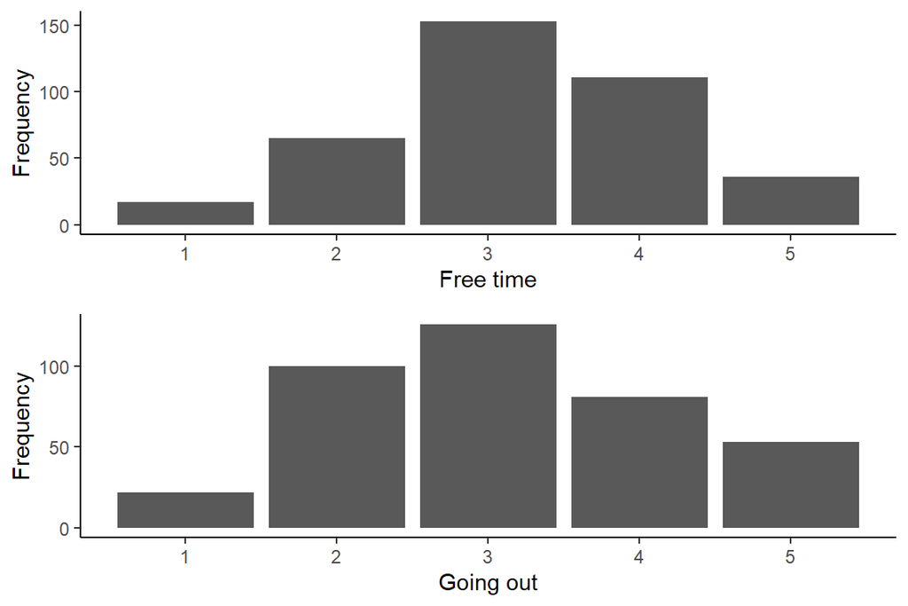

```r
freetime_aes <- ggplot(data, aes(data$freetime))
goout_aes <- ggplot(data, aes(data$goout))
B1 <- freetime_aes + geom_bar() + labs(x = "Free time", y = "Frequency") + theme_classic()
B2 <- goout_aes + geom_bar() + labs(x = "Going out", y = "Frequency") + theme_classic()
gridExtra::grid.arrange(B1, B2, nrow = 2)
```

Bar plots confirms that the two interval variables seem to follow approximately the gaussian distribution. Next let’s see how each of the explanatory variables are related to the response variable “high_use”.

**Participant gender x High use (cross-tabulation)**

```r
summarytools::ctable(data$sex, data$high_use)
```

```
## Cross-Tabulation, Row Proportions
## data$sex * data$high_use
##
## ---------- --------------- ------------- ------------- --------------
##              data$high_use         FALSE          TRUE          Total
##   data$sex
##          F                   156 (78.8%)    42 (21.2%)   198 (100.0%)
##          M                   112 (60.9%)    72 (39.1%)   184 (100.0%)
##      Total                   268 (70.2%)   114 (29.8%)   382 (100.0%)
## ---------- --------------- ------------- ------------- --------------
```

```r
chi1 <- chisq.test(data$sex, data$high_use)
chi1
```

```
##
##  Pearson's Chi-squared test with Yates' continuity correction
##
## data:  data$sex and data$high_use
## X-squared = 13.782, df = 1, p-value = 0.0002053
```

```r
round(chi1$residuals, 3)
```

```
##         data$high_use
## data$sex  FALSE   TRUE
##        F  1.450 -2.223
##        M -1.504  2.306
```

There seems to be a statistically significant association between participant gender and heavy drinking, X2(1) = 13.782, p < .001. From the residuals we can see that females are more represented in the FALSE category and less in the TRUE category than what would be expected if the counts were equally distributed among the cells in the cross-tabulation. Opposite trend can be observed for males. Seems that our initial guess was a correct, males are more likely to be high drinkers than females (39.1 % vs 21.2 %, respectively).

**Extra-curricular activities x High use (cross-tabulation)**

```
## Cross-Tabulation, Row Proportions
## data$activities * data$high_use
##
## ----------------- --------------- ------------- ------------- --------------
##                     data$high_use         FALSE          TRUE          Total
##   data$activities
##                no                   122 (67.4%)    59 (32.6%)   181 (100.0%)
##               yes                   146 (72.6%)    55 (27.4%)   201 (100.0%)
##             Total                   268 (70.2%)   114 (29.8%)   382 (100.0%)
## ----------------- --------------- ------------- ------------- --------------
```

```
##
##  Pearson's Chi-squared test with Yates' continuity correction
##
## data:  data$activities and data$high_use
## X-squared = 1.0085, df = 1, p-value = 0.3153
```

```
##                data$high_use
## data$activities  FALSE   TRUE
##             no  -0.442  0.678
##             yes  0.420 -0.644
```

At first glance, it seems that there is a association between being involved in extra-curricular activities and drinking less (27.4 % vs 32.6 % for high drinking). However, inspection of the chi-square statistic indicates that this association is rather faint, and not statistically significant at the .05 alpha level, X2(1) = 1.0085, p = .32.

**Free time x High use (cross-tabulation)**

```
## Cross-Tabulation, Row Proportions
## data$freetime * data$high_use
##
## --------------- --------------- ------------- ------------- --------------
##                   data$high_use         FALSE          TRUE          Total
##   data$freetime
##               1                    15 (88.2%)     2 (11.8%)    17 (100.0%)
##               2                    49 (75.4%)    16 (24.6%)    65 (100.0%)
##               3                   113 (73.9%)    40 (26.1%)   153 (100.0%)
##               4                    70 (63.1%)    41 (36.9%)   111 (100.0%)
##               5                    21 (58.3%)    15 (41.7%)    36 (100.0%)
##           Total                   268 (70.2%)   114 (29.8%)   382 (100.0%)
## --------------- --------------- ------------- ------------- --------------
```

```
##
##  Pearson's Chi-squared test
##
## data:  data$freetime and data$high_use
## X-squared = 9.5739, df = 4, p-value = 0.04825
```

```
##              data$high_use
## data$freetime  FALSE   TRUE
##             1  0.890 -1.364
##             2  0.503 -0.771
##             3  0.546 -0.838
##             4 -0.892  1.368
##             5 -0.847  1.299
```

The p-value associateed with the test statistic barely undercuts the conventional .05 alpha level, X2(4) = 9.5739, p = .04825. From the residuals we can see that the strongest negative assocciation between the two variable levels seem to be between “freetime” value 1 and when “high_use” is TRUE, and strongest positive association when “freetime” value is 4 or 5 and “high_use” is TRUE. This indicates that there is a association between having lot’s of free time and also being a heavy drinker (the same trend can also be noted when cross-tabulation percentages are eyeballed).

**Going out x High use (cross-tabulation)**

```
## Cross-Tabulation, Row Proportions
## data$goout * data$high_use
##
## ------------ --------------- ------------- ------------- --------------
##                data$high_use         FALSE          TRUE          Total
##   data$goout
##            1                    19 (86.4%)     3 (13.6%)    22 (100.0%)
##            2                    84 (84.0%)    16 (16.0%)   100 (100.0%)
##            3                   103 (81.7%)    23 (18.3%)   126 (100.0%)
##            4                    41 (50.6%)    40 (49.4%)    81 (100.0%)
##            5                    21 (39.6%)    32 (60.4%)    53 (100.0%)
##        Total                   268 (70.2%)   114 (29.8%)   382 (100.0%)
## ------------ --------------- ------------- ------------- --------------
```

```
##
##  Pearson's Chi-squared test
##
## data:  data$goout and data$high_use
## X-squared = 58.368, df = 4, p-value = 6.388e-12
```

```
##           data$high_use
## data$goout  FALSE   TRUE
##          1  0.908 -1.391
##          2  1.653 -2.534
##          3  1.553 -2.381
##          4 -2.100  3.219
##          5 -2.654  4.069
```

Looking at the percentages it seems clear that going out more often is associated with high alcohol use (from “goout” values 1 to 3 percentage of high users are 13.6-18.3 %, and from values 4 to 5 percentage of high users are 49.4-60.4 %). The chi-square statistic and respective residuals give support for this observation, X2(4) = 58.368, p < .001.

To sum up, the cross-tabulations and associated chi-square tests seem to provide some support for our initial hypotheses concerning the relation between high alcohol use and the explanatory variables (with exception of “activities” and “high_use”). Next, we will investigate how these variables can be used to predict high alcohol use in logistic regression model.

#### **Logistic regression: Model fitting and interpretation**

Based on our earlier inspections, it seems that participant gender and how often participant goes out with friends are the best predictors of high alcohol use. So we’ll start with a model where “sex” and “goout” are used to predict “high_use” and then we’ll add the rest of the explanatory variables to see if our model fit improves.

**Model 1: High alchohol use ~ Participant gender + Going out with friends**

```r
model1 <- glm(high_use ~ goout + sex, family=binomial(link='logit'), data=data)
summary(model1)
```

```
##
## Call:
## glm(formula = high_use ~ goout + sex, family = binomial(link = "logit"),
##     data = data)
##
## Deviance Residuals:
##     Min       1Q   Median       3Q      Max
## -1.5599  -0.8726  -0.6260   0.8382   2.4893
##
## Coefficients:
##             Estimate Std. Error z value Pr(>|z|)
## (Intercept)  -3.8130     0.4529  -8.420  < 2e-16 ***
## goout         0.7609     0.1181   6.441 1.19e-10 ***
## sexM          0.8736     0.2466   3.543 0.000396 ***
## ---
## Signif. codes:  0 '***' 0.001 '**' 0.01 '*' 0.05 '.' 0.1 ' ' 1
##
## (Dispersion parameter for binomial family taken to be 1)
##
##     Null deviance: 465.68  on 381  degrees of freedom
## Residual deviance: 402.74  on 379  degrees of freedom
## AIC: 408.74
##
## Number of Fisher Scoring iterations: 4
```

**Model 2: High alchohol use ~ Participant gender + Going out with friends + Leisure time + Extra-curricular activities**

```r
model2 <- glm(high_use ~ goout + sex + freetime + activities, family=binomial(link='logit'), data=data)
summary(model2)
```

```
##
## Call:
## glm(formula = high_use ~ goout + sex + freetime + activities,
##     family = binomial(link = "logit"), data = data)
##
## Deviance Residuals:
##     Min       1Q   Median       3Q      Max
## -1.7013  -0.8085  -0.5526   0.8744   2.6147
##
## Coefficients:
##               Estimate Std. Error z value Pr(>|z|)
## (Intercept)   -3.79200    0.55553  -6.826 8.74e-12 ***
## goout          0.76105    0.12364   6.155 7.49e-10 ***
## sexM           0.92216    0.25420   3.628 0.000286 ***
## freetime       0.06094    0.13468   0.452 0.650949
## activitiesyes -0.47586    0.25025  -1.902 0.057226 .
## ---
## Signif. codes:  0 '***' 0.001 '**' 0.01 '*' 0.05 '.' 0.1 ' ' 1
##
## (Dispersion parameter for binomial family taken to be 1)
##
##     Null deviance: 465.68  on 381  degrees of freedom
## Residual deviance: 398.95  on 377  degrees of freedom
## AIC: 408.95
##
## Number of Fisher Scoring iterations: 4
```

```r
lmtest::lrtest(model1, model2)
```

```
## Likelihood ratio test
##
## Model 1: high_use ~ goout + sex
## Model 2: high_use ~ goout + sex + freetime + activities
##   #Df  LogLik Df  Chisq Pr(>Chisq)
## 1   3 -201.37
## 2   5 -199.47  2 3.7952     0.1499
```

First of all, we can see that “goout” and “sex” are significant predictors of “high_use” in both models, while “freetime” and “activities” are not when all the other variables are kept constant in the model. Including “freetime” and “activities” does not noticeably change the coefficients of “goout” and “sex”. Moreover, when model 1 and 2 are compared against the null model (i.e. intercept only) we can see that there is a slight decrease in residual deviance in model 2 compared to model 1, but AIC ([Akaike Information Criterion](https://en.wikipedia.org/wiki/Akaike_information_criterion)), which also takes into account how many new variables have been added (i.e. risk of overfitting), does not decrease. This is also confirmed by the partial likelihood ratio test, which indicates that the two models are not significantly different in their fits for the data (p = .15). Taken together, this means that we are probably better off predicting “high_use” with the simpler model 1.

**Interpreting the model coefficients**

```r
OR <- coef(model1) %>% exp
CI <- confint(model1) %>% exp
cbind(OR, CI)
```

```
##                     OR       2.5 %     97.5 %
## (Intercept) 0.02208168 0.008754964 0.05186666
## goout       2.14025612 1.708110942 2.71701439
## sexM        2.39559680 1.484457552 3.91015147
```

The model coefficients represent the expected change in the log odds of “high_use” when the particular explanatory variable increases one unit (keeping all the other variables constant in the model). The odds ratio is calculated by taking exp() function of these coefficients, and thus indicates the proportionate change in odds between the explanatory variable levels. Here, OR for “goout” is 2.14 which means that when “goout” variable increases one unit, the odds of participant belonging to high alcohol use category are, on average, 2.14 times greater. “Sex” is a binary variable but the interperation is much the same, when one unit increase takes place (i.e. when we go from female to male category) odds of belonging to high alcohol use category goes up 2.40 times. Thus, both, being a male and going out with friends more often, increases the participants risk of being a heavy drinker (which is in line with our earlier hypotheses). Confidence intervals indicate that the direction of the ORs received here will likely be same as they are in the population (CIs dont include 1).

**Model accuracy**

```r
probabilities <- predict(model1, type = "response")
data <- mutate(data, probability = probabilities)
data <- mutate(data, prediction = probability > 0.5)
table(high_use = data$high_use, prediction = data$prediction)
```

```
##         prediction
## high_use FALSE TRUE
##    FALSE   251   17
##    TRUE     63   51
```

```r
InformationValue::misClassError(data$high_use, data$prediction, threshold = 0.5)
```

```
## [1] 0.2094
```

From here we can see that our model correctly identifies 251 out of 268 cases as being “moderate drinkers”, and 51 out of 114 cases as being heavy drinkers (when treshold level is kept at 0.5). This leads to average number of wrong predictions being 0.2094 (i.e. accuracy is approximately 79 %). Even though our model is quite good at predicting **who is not a heavy drinker** (251/268 = 0.94) it performs worse than change level alone when predicting **who is a heavy drinker** (51/114 = 0.45).

Before wrapping up, let’s take a quick look at some of the model diagnostics.

**Model diagnostics**

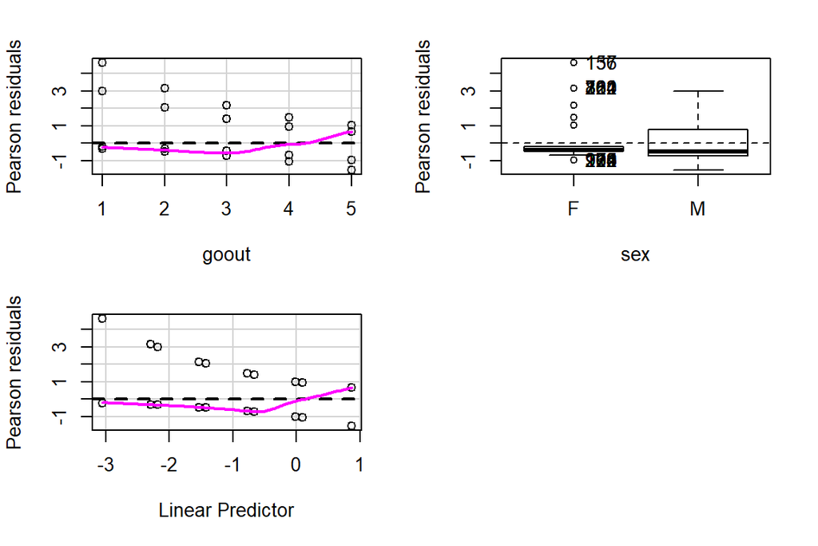

```
##       Test stat Pr(>|Test stat|)
## goout    1.3564           0.2442
## sex
```

```r
car::residualPlots(model1)
```

Above we have plotted the pearson residuals of the model against the predictors fitted values. Ideally we would see straight horizontal line without curvature indicating that there is correlation between residuals and the fitted values. Here, slight curvature can be seen, but, as the more formal test of curvature indicates, there does not seem to be a major problem with-in the model (p = .24).

Next we’ll check if we can spot any outliers in the model.

```r
car::outlierTest(model1)
```

```
## No Studentized residuals with Bonferroni p < 0.05
## Largest |rstudent|:
##     rstudent unadjusted p-value Bonferroni p
## 136 2.511506           0.012022           NA
```

The results show that there is no outliers as judged by Bonferonni p. Largest studenized residual seems to be 2.51 (for case 136), which is still not alarmingly large (i.e. above 3).

Next let’s see if we can find influential values in our model.

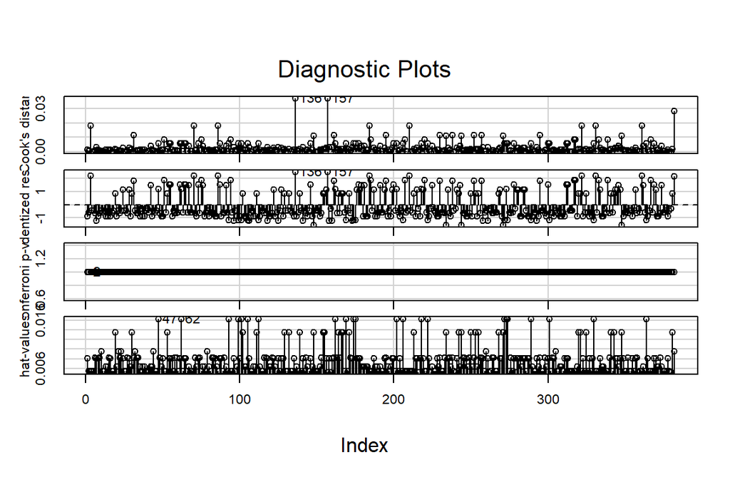

```r
car::influenceIndexPlot(model1)
```

Here the most interesting plot is the one showing the Cook’s distance values. The same case that was mentioned earlier (136) is highlighted also here. However, all of the Cooks distance values are rather low (<.04), so we probably don’t have cause for serious concern.

**Bonus: Cross-validitation**

```r
loss_func <- function(class, prob) {
  n_wrong <- abs(class - prob) > 0.5
  mean(n_wrong)
}

loss_func(data$high_use, data$probability)
```

```
## [1] 0.2094241
```

```r
library(boot)
cv <- cv.glm(data = data, cost = loss_func, glmfit = model1, K = 10)
cv$delta[1]
```

```
## [1] 0.2539267
```

# **RStudio Exercise 4: Clustering and classification**

#### **Oppening the data file and inspecting data structure**:

```r
library(MASS)
data("Boston")
data <- as.data.frame(Boston)
str(data)
```

```
## 'data.frame':    506 obs. of  14 variables:
##  $ crim   : num  0.00632 0.02731 0.02729 0.03237 0.06905 ...
##  $ zn     : num  18 0 0 0 0 0 12.5 12.5 12.5 12.5 ...
##  $ indus  : num  2.31 7.07 7.07 2.18 2.18 2.18 7.87 7.87 7.87 7.87 ...
##  $ chas   : int  0 0 0 0 0 0 0 0 0 0 ...
##  $ nox    : num  0.538 0.469 0.469 0.458 0.458 0.458 0.524 0.524 0.524 0.524 ...
##  $ rm     : num  6.58 6.42 7.18 7 7.15 ...
##  $ age    : num  65.2 78.9 61.1 45.8 54.2 58.7 66.6 96.1 100 85.9 ...
##  $ dis    : num  4.09 4.97 4.97 6.06 6.06 ...
##  $ rad    : int  1 2 2 3 3 3 5 5 5 5 ...
##  $ tax    : num  296 242 242 222 222 222 311 311 311 311 ...
##  $ ptratio: num  15.3 17.8 17.8 18.7 18.7 18.7 15.2 15.2 15.2 15.2 ...
##  $ black  : num  397 397 393 395 397 ...
##  $ lstat  : num  4.98 9.14 4.03 2.94 5.33 ...
##  $ medv   : num  24 21.6 34.7 33.4 36.2 28.7 22.9 27.1 16.5 18.9 ...
```

```r
dim(data)
```

```
## [1] 506  14
```

```r
any(is.na.data.frame(data))
```

```
## [1] FALSE
```

From here we can see that there are 14 variables (columns) and 506 observations (rows) in the data set and no missing values. All variables are either numerical or integer. The data is described in detail **[HERE](https://stat.ethz.ch/R-manual/R-devel/library/MASS/html/Boston.html)**. The following variables are included:

- **crim** = per capita crime rate by town.
- **zn** = proportion of residential land zoned for lots over 25,000 sq.ft.
- **indus** = proportion of non-retail business acres per town..
- **chas** = Charles River dummy variable (= 1 if tract bounds river; 0 otherwise).
- **nox** = nitrogen oxides concentration (parts per 10 million).
- **rm** = average number of rooms per dwelling.
- **age** = proportion of owner-occupied units built prior to 1940.
- **dis** = weighted mean of distances to five Boston employment centres.
- **rad** = index of accessibility to radial highways.
- **tax** = full-value property-tax rate per $10,000.
- **ptratio** = pupil-teacher ratio by town.
- **black** = 1000(Bk - 0.63)^2 where Bk is the proportion of blacks by town.
- **lstat** = lower status of the population (percent).
- **medv** = median value of owner-occupied homes in $1000s.

#### **Graphical overview of the data and summaries:**

Let’s first inspect the univariate normality of the variables.

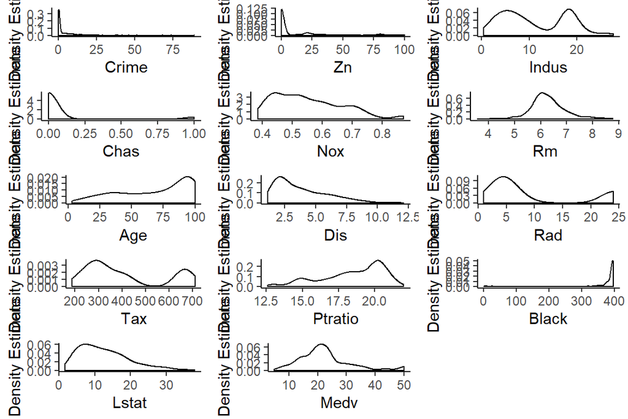

```r
crim_aes <- ggplot(data, aes(data$crim))
zn_aes <- ggplot(data, aes(data$zn))
indus_aes <- ggplot(data, aes(data$indus))
chas_aes <- ggplot(data, aes(data$chas))
nox_aes <- ggplot(data, aes(data$nox))
rm_aes <- ggplot(data, aes(data$rm))
age_aes <- ggplot(data, aes(data$age))
dis_aes <- ggplot(data, aes(data$dis))
rad_aes <- ggplot(data, aes(data$rad))
tax_aes <- ggplot(data, aes(data$tax))
ptratio_aes <- ggplot(data, aes(data$ptratio))
black_aes <- ggplot(data, aes(data$black))
lstat_aes <- ggplot(data, aes(data$lstat))
medv_aes <- ggplot(data, aes(data$medv))

D1 <- crim_aes + geom_density() + labs(x = "Crime", y = "Density Estimate") + theme_classic()
D2 <- zn_aes + geom_density() + labs(x = "Zn", y = "Density Estimate") + theme_classic()
D3 <- indus_aes + geom_density() + labs(x = "Indus", y = "Density Estimate") + theme_classic()
D4 <- chas_aes + geom_density() + labs(x = "Chas", y = "Density Estimate") + theme_classic()
D5 <- nox_aes + geom_density() + labs(x = "Nox", y = "Density Estimate") + theme_classic()
D6 <- rm_aes + geom_density() + labs(x = "Rm", y = "Density Estimate") + theme_classic()
D7 <- age_aes + geom_density() + labs(x = "Age", y = "Density Estimate") + theme_classic()
D8 <- dis_aes + geom_density() + labs(x = "Dis", y = "Density Estimate") + theme_classic()
D9 <- rad_aes + geom_density() + labs(x = "Rad", y = "Density Estimate") + theme_classic()
D10 <- tax_aes + geom_density() + labs(x = "Tax", y = "Density Estimate") + theme_classic()
D11 <- ptratio_aes + geom_density() + labs(x = "Ptratio", y = "Density Estimate") + theme_classic()
D12 <- black_aes + geom_density() + labs(x = "Black", y = "Density Estimate") + theme_classic()
D13 <- lstat_aes + geom_density() + labs(x = "Lstat", y = "Density Estimate") + theme_classic()
D14 <- medv_aes + geom_density() + labs(x = "Medv", y = "Density Estimate") + theme_classic()

gridExtra::grid.arrange(D1, D2, D3, D4, D5, D6, D7, D8, D9, D10, D11, D12, D13, D14, nrow = 5)
```

It seems clear from the density plots that none of the variables are very normally distributed (with possibly the exception of “rm”). Let’s also check the data with box-plots. It is also noteworthy that the variables have been measured using very different scales (e.g. “dis” = 2.5 to 12.5 vs “tax” = 200 to 700)

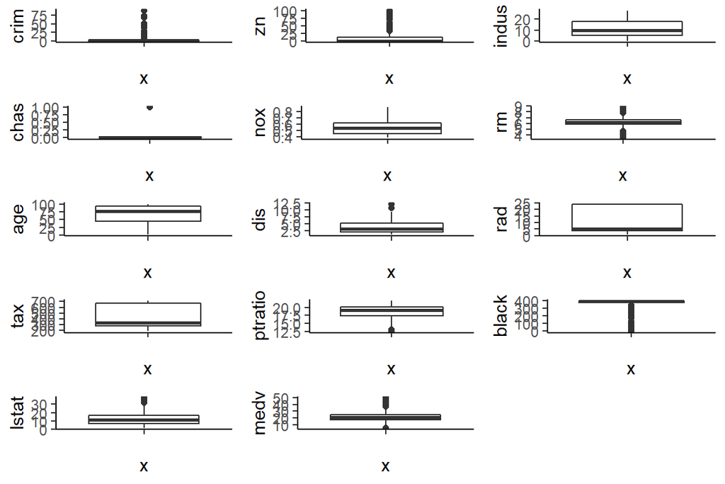

```r
B1 <- ggplot(data = data, aes(x = "", y = crim)) + geom_boxplot() + theme_classic()
B2 <- ggplot(data = data, aes(x = "", y = zn)) + geom_boxplot() + theme_classic()
B3 <- ggplot(data = data, aes(x = "", y = indus)) + geom_boxplot() + theme_classic()
B4 <- ggplot(data = data, aes(x = "", y = chas)) + geom_boxplot() + theme_classic()
B5 <- ggplot(data = data, aes(x = "", y = nox)) + geom_boxplot() + theme_classic()
B6 <- ggplot(data = data, aes(x = "", y = rm)) + geom_boxplot() + theme_classic()
B7 <- ggplot(data = data, aes(x = "", y = age)) + geom_boxplot() + theme_classic()
B8 <- ggplot(data = data, aes(x = "", y = dis)) + geom_boxplot() + theme_classic()
B9 <- ggplot(data = data, aes(x = "", y = rad)) + geom_boxplot() + theme_classic()
B10 <- ggplot(data = data, aes(x = "", y = tax)) + geom_boxplot() + theme_classic()
B11 <- ggplot(data = data, aes(x = "", y = ptratio)) + geom_boxplot() + theme_classic()
B12 <- ggplot(data = data, aes(x = "", y = black)) + geom_boxplot() + theme_classic()
B13 <- ggplot(data = data, aes(x = "", y = lstat)) + geom_boxplot() + theme_classic()
B14 <- ggplot(data = data, aes(x = "", y = medv)) + geom_boxplot() + theme_classic()

gridExtra::grid.arrange(B1, B2, B3, B4, B5, B6, B7, B8, B9, B10, B11, B12, B13, B14, ncol = 3)
```

Box-plots confirms what we saw earlier from the density plots, all of the variables are more or less skewed and indicate departure from the gaussian distribution. Box-plots also highlights the potential outliers that are present in many of the variables. For example, it seems that the “rm” contains lot of outliers on both ends of the distribution (which was also reflected in the long tails of the density plot).

Since the univariate plots strongly indicates non-normality, the data will not satisfy multivariate normality either. But just to be sure, let’s order a plot of squared [Mahalanobis distance values](https://en.wikipedia.org/wiki/Mahalanobis_distance) of the data versus quantiles of the chi-square distribution. If the data comes from multivariate normal distribution the squared Mahalanobis distance values should approximate the chi-square distribution.

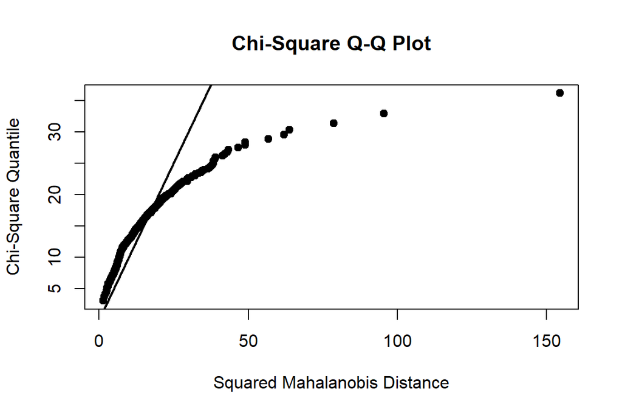

```r
Multiv <- mvn(data, mvnTest= "hz", multivariatePlot= "qq")
```

Here, we can see a clear departure from normality, as was expected based on the univariate plots.